# Lab 18

# Set-up

Read in the following libraries and to load the metadata about the FMNIST (fashion) dataset:

```r
reticulate::use_python("/anaconda3/bin/python")

library(readr)
library(dplyr)
library(glmnet)
library(keras)

fmnist <- read_csv("https://statsmaths.github.io/ml_data/fashion_10.csv")
```

To get the actual data for the images, you’ll have to download the fmnist file from here:

- https://drive.google.com/drive/folders/14k9wNUTUEB3hAjXS8wfXty5_uACu3ZXq

Once this is downloaded, you’ll have to run something like this:

```r
x28 <- read_rds("../notes/image_data/fashion_10_x28.rds")
```

If you have trouble with any of this, please let me know as soon as possible.

# Todays lab

The only thing you need to do today is to play around with different models and see how well they work. Once you are satisfied, pick the best model and incorporate the predictions into your output in the final chunk below. Note: I would suggest keeping each model in its own code chunk for readability. Also, save your work frequently as it is quite likely that you will crash R at some point.

```r
X <- t(apply(x28, 1, cbind))
y <- fmnist$class

X_train <- X[fmnist$train_id == "train",]
y_train <- to_categorical(y[fmnist$train_id == "train"])
```

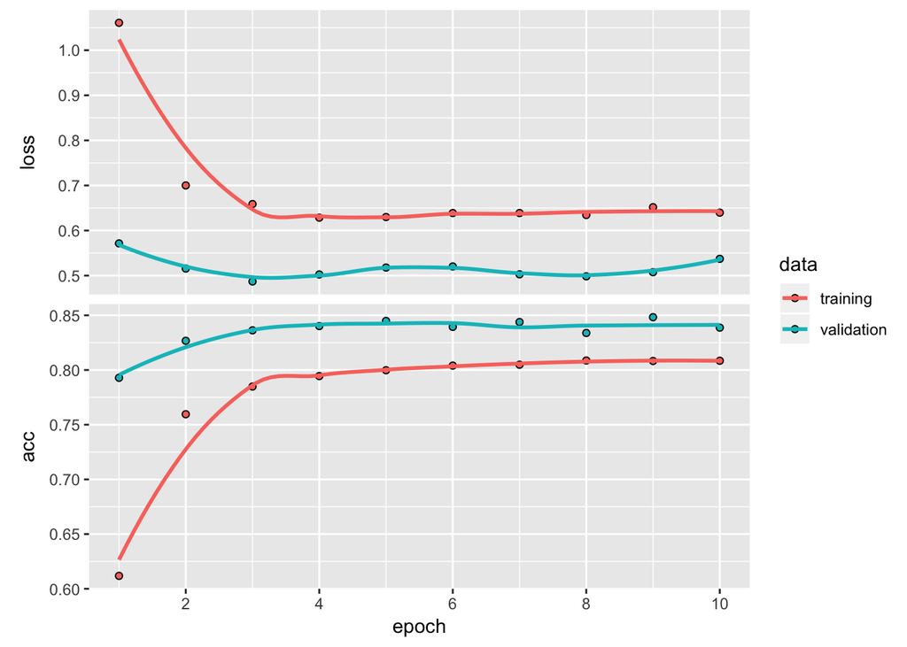

```r
model <- keras_model_sequential()
model %>%
  layer_dense(units = 128, input_shape = ncol(X_train)) %>%
  layer_activation(activation = "relu") %>%
  layer_dropout(rate = 0.5) %>%

  layer_dense(units = 128) %>%
  layer_activation(activation = "relu") %>%
  layer_dropout(rate = 0.5) %>%

  layer_dense(units = 128) %>%
  layer_activation(activation = "relu") %>%
  layer_dropout(rate = 0.5) %>%

  layer_dense(units = ncol(y_train)) %>%
  layer_activation(activation = "softmax")

model %>% compile(loss = 'categorical_crossentropy',
                  optimizer = optimizer_rmsprop(),
                  metrics = c('accuracy'))

history <- model %>%
  fit(X_train, y_train, epochs = 10, validation_split = 0.2)
plot(history)
```

Finally, run a prediction on the “real” validation set:

```r
pred <- predict_classes(model, X)
tapply(y == pred, fmnist$train_id, mean)
```

```
##      test     train     valid
##        NA 0.8497429 0.8446286
```

```r
table(y[fmnist$train_id == "train"], pred[fmnist$train_id == "train"])
```

```
##
##        0    1    2    3    4    5    6    7    8    9
##   0 2342    4   21  202    6    0  906    0   17    2
##   1    1 3373   15   93    5    0   12    0    1    0
##   2   19    0 2605   70  524    0  278    0    4    0
##   3   37   31    2 3281   26    0  122    0    1    0
##   4    0    3  228  373 2699    0  190    2    5    0
##   5    2    0    0    0    0 3280    1  173    6   38
##   6  264    5  407  171  418    0 2207    1   26    1
##   7    0    0    0    0    0   40    0 3356    6   98
##   8    5    2   34   28   12    8  111   22 3275    3
##   9    0    0    0    0    0   30    1  146    0 3323
```

# Submission

The code below assumes that you have added a prediction named `pred` to every row of the dataset.

```r
submit <- select(fmnist, obs_id, train_id)
submit <- mutate(submit, pred = pred)
write_csv(submit, "class18_submit.csv")
```

Now, upload the csv file to GitHub and you are done.